# Project: Analysing Movie Data

- Introduction
- Data Wrangling
- Exploratory Data Analysis
- Conclusions

## Introduction

> The TMDb dataset was chosen for this project. This data set contains information about 10,000 movies collected from The Movie Database (TMDb), including user ratings and revenue. We will conduct som data wrangling and then answer a set of questions about the data.

Following questions will be answered in the course of this analysis:

> General questions:
> - Which year had the highest votes on average?
> - Has there been an increase in movie entries for tmdb?
> - How have movie ratings developed over the course of the years?
> - Which directors produced most movies?

> Research questions:
> - Research Question 1: Which genres are most popular from year to year?
> - Research Question 2: What kinds of properties are associated with movies that have high revenues?
> - Research question 3: Are movies from before 2000 better than after 2000?

```python
import numpy as np
import pandas as pd
import matplotlib.pyplot as plt
import seaborn as sns

from pandas.plotting import scatter_matrix
from scipy.stats import ttest_ind

sns.set_style('darkgrid')
pd.set_option('display.max_columns', None)


%matplotlib inline
```

## Data Wrangling

In this section of the report, the data will be loaded and checked for cleanliness, so it can be trimmed and cleaned for analysis

### General Properties

```python
# Load data and print out first lines
df = pd.read_csv('tmdb-movies.csv')
df.head()
```

|  | id | imdb_id | popularity | budget | revenue | original_title | cast | homepage | director | tagline | keywords | overview | runtime | genres | production_companies | release_date | vote_count | vote_average | release_year | budget_adj | revenue_adj |
| --- | --- | --- | --- | --- | --- | --- | --- | --- | --- | --- | --- | --- | --- | --- | --- | --- | --- | --- | --- | --- | --- |
| 0 | 135397 | tt0369610 | 32.985763 | 150000000 | 1513528810 | Jurassic World | Chris Pratt\|Bryce Dallas Howard\|Irrfan Khan\|Vi... | http://www.jurassicworld.com/ | Colin Trevorrow | The park is open. | monster\|dna\|tyrannosaurus rex\|velociraptor\|island | Twenty-two years after the events of Jurassic ... | 124 | Action\|Adventure\|Science Fiction\|Thriller | Universal Studios\|Amblin Entertainment\|Legenda... | 6/9/15 | 5562 | 6.5 | 2015 | 1.379999e+08 | 1.392446e+09 |
| 1 | 76341 | tt1392190 | 28.419936 | 150000000 | 378436354 | Mad Max: Fury Road | Tom Hardy\|Charlize Theron\|Hugh Keays-Byrne\|Nic... | http://www.madmaxmovie.com/ | George Miller | What a Lovely Day. | future\|chase\|post-apocalyptic\|dystopia\|australia | An apocalyptic story set in the furthest reach... | 120 | Action\|Adventure\|Science Fiction\|Thriller | Village Roadshow Pictures\|Kennedy Miller Produ... | 5/13/15 | 6185 | 7.1 | 2015 | 1.379999e+08 | 3.481613e+08 |
| 2 | 262500 | tt2908446 | 13.112507 | 110000000 | 295238201 | Insurgent | Shailene Woodley\|Theo James\|Kate Winslet\|Ansel... | http://www.thedivergentseries.movie/#insurgent | Robert Schwentke | One Choice Can Destroy You | based on novel\|revolution\|dystopia\|sequel\|dyst... | Beatrice Prior must confront her inner demons ... | 119 | Adventure\|Science Fiction\|Thriller | Summit Entertainment\|Mandeville Films\|Red Wago... | 3/18/15 | 2480 | 6.3 | 2015 | 1.012000e+08 | 2.716190e+08 |
| 3 | 140607 | tt2488496 | 11.173104 | 200000000 | 2068178225 | Star Wars: The Force Awakens | Harrison Ford\|Mark Hamill\|Carrie Fisher\|Adam D... | http://www.starwars.com/films/star-wars-episod... | J.J. Abrams | Every generation has a story. | android\|spaceship\|jedi\|space opera\|3d | Thirty years after defeating the Galactic Empi... | 136 | Action\|Adventure\|Science Fiction\|Fantasy | Lucasfilm\|Truenorth Productions\|Bad Robot | 12/15/15 | 5292 | 7.5 | 2015 | 1.839999e+08 | 1.902723e+09 |
| 4 | 168259 | tt2820852 | 9.335014 | 190000000 | 1506249360 | Furious 7 | Vin Diesel\|Paul Walker\|Jason Statham\|Michelle ... | http://www.furious7.com/ | James Wan | Vengeance Hits Home | car race\|speed\|revenge\|suspense\|car | Deckard Shaw seeks revenge against Dominic Tor... | 137 | Action\|Crime\|Thriller | Universal Pictures\|Original Film\|Media Rights ... | 4/1/15 | 2947 | 7.3 | 2015 | 1.747999e+08 | 1.385749e+09 |

Data seems to have the right data types for analysis!

```python
df.dtypes
```

```
id                        int64
imdb_id                  object
popularity              float64
budget                    int64
revenue                   int64
original_title           object
cast                     object
homepage                 object
director                 object
tagline                  object
keywords                 object
overview                 object
runtime                   int64
genres                   object
production_companies     object
release_date             object
vote_count                int64
vote_average            float64
release_year              int64
budget_adj              float64
revenue_adj             float64
dtype: object
```

There are 10866 observations in our data set. It stands out that 'homepage' has a lot of NaN values. However, none of the int64 columns have NaN values. Therefore, we do not need to replace any numerical NaN values.

```python
df.info()
```

```
<class 'pandas.core.frame.DataFrame'>
RangeIndex: 10866 entries, 0 to 10865
Data columns (total 21 columns):
id                      10866 non-null int64
imdb_id                 10856 non-null object
popularity              10866 non-null float64
budget                  10866 non-null int64
revenue                 10866 non-null int64
original_title          10866 non-null object
cast                    10790 non-null object
homepage                2936 non-null object
director                10822 non-null object
tagline                 8042 non-null object
keywords                9373 non-null object
overview                10862 non-null object
runtime                 10866 non-null int64
genres                  10843 non-null object
production_companies    9836 non-null object
release_date            10866 non-null object
vote_count              10866 non-null int64
vote_average            10866 non-null float64
release_year            10866 non-null int64
budget_adj              10866 non-null float64
revenue_adj             10866 non-null float64
dtypes: float64(4), int64(6), object(11)
memory usage: 1.7+ MB
```

It turns out that there is one duplicate row in the data set

```python
df.duplicated().sum()
```

```
1
```

In total there are 8874 rows which contain at least one NaN value:

```python
df.isnull().any(axis=1).sum()
```

```
8874
```

```python
df.isnull().sum() # NaN values for each row
```

```
id                         0
imdb_id                   10
popularity                 0
budget                     0
revenue                    0
original_title             0
cast                      76
homepage                7930
director                  44
tagline                 2824
keywords                1493
overview                   4
runtime                    0
genres                    23
production_companies    1030
release_date               0
vote_count                 0
vote_average               0
release_year               0
budget_adj                 0
revenue_adj                0
dtype: int64
```

> Looking at some of the minimums, it seems that there are properties are zero which are most likely wrong (i.e. budget, revenue, budget_adj and revenue_adj)

```python
df.describe()
```

|  | id | popularity | budget | revenue | runtime | vote_count | vote_average | release_year | budget_adj | revenue_adj |
| --- | --- | --- | --- | --- | --- | --- | --- | --- | --- | --- |
| count | 10866.000000 | 10866.000000 | 1.086600e+04 | 1.086600e+04 | 10866.000000 | 10866.000000 | 10866.000000 | 10866.000000 | 1.086600e+04 | 1.086600e+04 |
| mean | 66064.177434 | 0.646441 | 1.462570e+07 | 3.982332e+07 | 102.070863 | 217.389748 | 5.974922 | 2001.322658 | 1.755104e+07 | 5.136436e+07 |
| std | 92130.136561 | 1.000185 | 3.091321e+07 | 1.170035e+08 | 31.381405 | 575.619058 | 0.935142 | 12.812941 | 3.430616e+07 | 1.446325e+08 |
| min | 5.000000 | 0.000065 | 0.000000e+00 | 0.000000e+00 | 0.000000 | 10.000000 | 1.500000 | 1960.000000 | 0.000000e+00 | 0.000000e+00 |
| 25% | 10596.250000 | 0.207583 | 0.000000e+00 | 0.000000e+00 | 90.000000 | 17.000000 | 5.400000 | 1995.000000 | 0.000000e+00 | 0.000000e+00 |
| 50% | 20669.000000 | 0.383856 | 0.000000e+00 | 0.000000e+00 | 99.000000 | 38.000000 | 6.000000 | 2006.000000 | 0.000000e+00 | 0.000000e+00 |
| 75% | 75610.000000 | 0.713817 | 1.500000e+07 | 2.400000e+07 | 111.000000 | 145.750000 | 6.600000 | 2011.000000 | 2.085325e+07 | 3.369710e+07 |
| max | 417859.000000 | 32.985763 | 4.250000e+08 | 2.781506e+09 | 900.000000 | 9767.000000 | 9.200000 | 2015.000000 | 4.250000e+08 | 2.827124e+09 |

### Data Cleaning

We will clean the data by removing duplicates, zero values, rows with too many NaN values and also remove outliers. While cleaning we also want to maintain the largest amount of data.

There is one duplicate row in the data set which is removed with the following command:

```python
df.drop_duplicates(inplace=True)
```

There are no duplicated IDs left!

```python
df.id.duplicated().sum() # check whether we have duplicate ID's which is even stricter than looking for duplicate rows.
```

```
0
```

The 'homepage' column has a lot of NaN values and provides little analytical relevance. Therefore, it can be dropped:

```python
df.drop('homepage', axis=1, inplace=True)
```

```python
df.query('revenue == 0').revenue.count() # zero counts for revenue
```

```
6016
```

```python
df.query('revenue_adj == 0').revenue_adj.count() # zero counts for revenue_adj
```

```
6016
```

```python
df.query('budget == 0').budget.count() # zero counts for budget
```

```
5696
```

```python
df.query('budget_adj == 0').budget_adj.count() # zero counts for budget_adj
```

```
5696
```

```python
df.query('vote_average == 0').vote_average.count() # zero counts for vote_avg
```

```
0
```

Also drop unadjusted revenue and budget counts as they are less usable for comparing. We will use the adjusted values instead.

```python
df_clean = df.drop('revenue', axis=1)
df_clean.drop('budget', axis=1, inplace=True)
```

```python
df_clean = df_clean[df.revenue_adj > 0] # create clean dataset by removing rows with movies which have no revenue data
```

```python
df_clean = df_clean[df_clean.budget_adj > 0] # clean dataset by removing rows with movies which have no budget data
```

```python
print(df_clean.shape, df.shape) # compare sizes of original and clean datasets
```

```
(3854, 18) (10865, 20)
```

Let's also remove outliers from revenue, budget and vote averages:

```python
df_clean = df_clean[np.abs(df_clean.budget_adj - df_clean.budget_adj.mean()) <= (3 * df_clean.budget_adj.std())]
df_clean.shape
```

```
(3786, 18)
```

```python
df_clean = df_clean[np.abs(df_clean.revenue_adj - df_clean.revenue_adj.mean()) <= (3 * df_clean.revenue_adj.std())]
df_clean.shape
```

```
(3707, 18)
```

```python
df_clean = df_clean[np.abs(df_clean.vote_average - df_clean.vote_average.mean()) <= (3 * df_clean.vote_average.std())]
df_clean.shape
```

```
(3694, 18)
```

We have now cleaned the dataset from values with missing budget and revenue. Also we have removed outliers in the data set. However, we lost many of the records. Therefore, for some questions we will use the original dataset and clean according to the question.

```python
df_clean.head()
```

|  | id | imdb_id | popularity | original_title | cast | director | tagline | keywords | overview | runtime | genres | production_companies | release_date | vote_count | vote_average | release_year | budget_adj | revenue_adj |
| --- | --- | --- | --- | --- | --- | --- | --- | --- | --- | --- | --- | --- | --- | --- | --- | --- | --- | --- |
| 1 | 76341 | tt1392190 | 28.419936 | Mad Max: Fury Road | Tom Hardy\|Charlize Theron\|Hugh Keays-Byrne\|Nic... | George Miller | What a Lovely Day. | future\|chase\|post-apocalyptic\|dystopia\|australia | An apocalyptic story set in the furthest reach... | 120 | Action\|Adventure\|Science Fiction\|Thriller | Village Roadshow Pictures\|Kennedy Miller Produ... | 5/13/15 | 6185 | 7.1 | 2015 | 1.379999e+08 | 3.481613e+08 |
| 2 | 262500 | tt2908446 | 13.112507 | Insurgent | Shailene Woodley\|Theo James\|Kate Winslet\|Ansel... | Robert Schwentke | One Choice Can Destroy You | based on novel\|revolution\|dystopia\|sequel\|dyst... | Beatrice Prior must confront her inner demons ... | 119 | Adventure\|Science Fiction\|Thriller | Summit Entertainment\|Mandeville Films\|Red Wago... | 3/18/15 | 2480 | 6.3 | 2015 | 1.012000e+08 | 2.716190e+08 |
| 5 | 281957 | tt1663202 | 9.110700 | The Revenant | Leonardo DiCaprio\|Tom Hardy\|Will Poulter\|Domhn... | Alejandro González Iñárritu | (n. One who has returned, as if from the dead.) | father-son relationship\|rape\|based on novel\|mo... | In the 1820s, a frontiersman, Hugh Glass, sets... | 156 | Western\|Drama\|Adventure\|Thriller | Regency Enterprises\|Appian Way\|CatchPlay\|Anony... | 12/25/15 | 3929 | 7.2 | 2015 | 1.241999e+08 | 4.903142e+08 |
| 6 | 87101 | tt1340138 | 8.654359 | Terminator Genisys | Arnold Schwarzenegger\|Jason Clarke\|Emilia Clar... | Alan Taylor | Reset the future | saving the world\|artificial intelligence\|cybor... | The year is 2029. John Connor, leader of the r... | 125 | Science Fiction\|Action\|Thriller\|Adventure | Paramount Pictures\|Skydance Productions | 6/23/15 | 2598 | 5.8 | 2015 | 1.425999e+08 | 4.053551e+08 |
| 7 | 286217 | tt3659388 | 7.667400 | The Martian | Matt Damon\|Jessica Chastain\|Kristen Wiig\|Jeff ... | Ridley Scott | Bring Him Home | based on novel\|mars\|nasa\|isolation\|botanist | During a manned mission to Mars, Astronaut Mar... | 141 | Drama\|Adventure\|Science Fiction | Twentieth Century Fox Film Corporation\|Scott F... | 9/30/15 | 4572 | 7.6 | 2015 | 9.935996e+07 | 5.477497e+08 |

## Exploratory Data Analysis

> Now that we've trimmed and cleaned our data, we're ready to move on to exploration. In this section we will compute statistics and create visualizations. We will also pose some research question. It is recommended that you be systematic with your approach. Look at one variable at a time, and then follow it up by looking at relationships between variables.

Let's do some correlation analysis first to find out about the relation between variables:

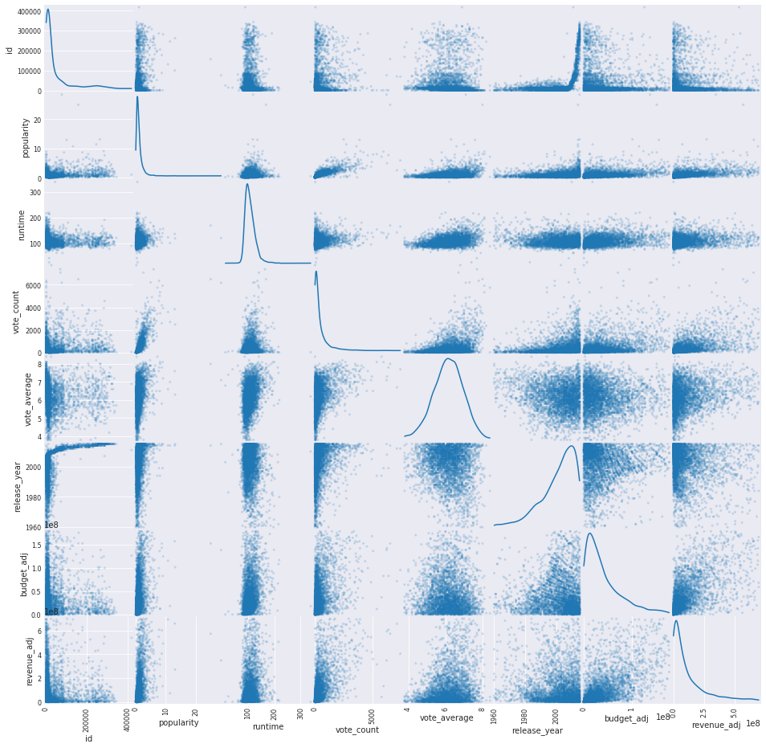

```python
scatter_matrix(df_clean, alpha=0.2, figsize=(16, 16), diagonal='kde');
```

> Vote average has characteristics of a normal distribution! Runtime is slightly skewed to the right.

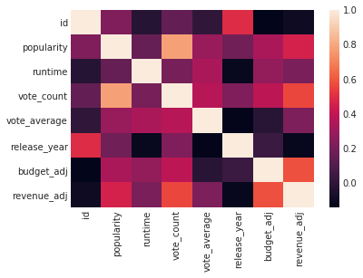

```python
corr = df_clean.corr()
sns.heatmap(corr,
            xticklabels=corr.columns.values,
            yticklabels=corr.columns.values);
```

Let's see if investments in producing movies generally pay off. Does the budget correlate with the final revenue?

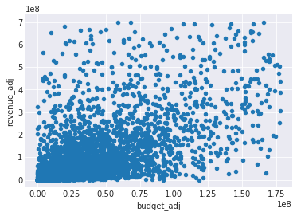

```python
df_clean.plot('budget_adj', 'revenue_adj', kind='scatter');
```

```python
np.corrcoef(df_clean.budget_adj, df_clean.revenue_adj)[0,1]
```

```
0.58480027103752175
```

> Looking at the correlation coefficient and the plot, there is a positive correlation between budget and revenue.

But does the budget also correlate with the user rating?

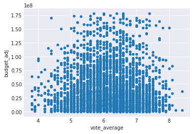

```python
df_clean.plot('vote_average', 'budget_adj', kind='scatter');
```

```python
np.corrcoef(df_clean.vote_average, df_clean.budget_adj)[0,1]
```

```
-0.019093818433324472
```

> No, the two variables do not correlate. Putting more money into a movie does not mean it can buy a higher rating.

Does the revenue have a relation to the user rating?

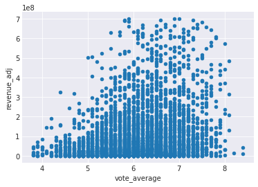

```python
df_clean.plot('vote_average', 'revenue_adj', kind='scatter');
```

```python
np.corrcoef(df_clean.vote_average, df_clean.revenue_adj)[0,1]
```

```
0.22139705757213696
```

> There is a slight correlation between users liking the movie and paying for it.

Looking at the vote average, we can see the distribution is approximately normal:

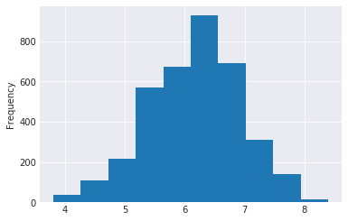

```python
df_clean.vote_average.plot(kind='hist');
```

Has there been an increase in movie entries for tmdb?

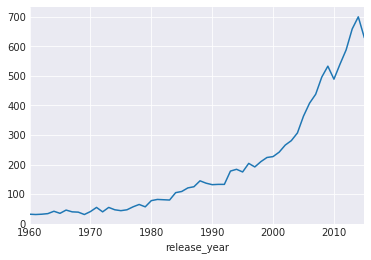

```python
df.groupby('release_year')['id'].count().plot(kind='line');
```

> We can see as strong uptrend of tmdb growing over the years. The decrease in the current year indicates the year not having ended yet.

Which year had the highest votes on average?

```python
df.groupby('release_year')['vote_average'].mean().idxmax() # get year with highest mean of vote_average
```

```
1973
```

Indeed, 1973 has some very high ranked movies:

```python
df.query('release_year == "1973"')[['original_title', 'vote_average']].sort_values('vote_average', ascending=False).head(20) # get top 20 movies from 1973
```

|  | original_title | vote_average |
| --- | --- | --- |
| 10601 | The Sting | 7.7 |
| 10613 | Paper Moon | 7.7 |
| 10627 | A Charlie Brown Thanksgiving | 7.6 |
| 10608 | Papillon | 7.4 |
| 10630 | The Holy Mountain | 7.4 |
| 10616 | Pat Garrett & Billy the Kid | 7.4 |
| 10611 | Serpico | 7.3 |
| 10622 | Badlands | 7.3 |
| 10635 | The Offence | 7.3 |
| 10594 | The Exorcist | 7.2 |
| 10603 | High Plains Drifter | 7.1 |
| 10596 | Mean Streets | 7.1 |
| 10623 | Coffy | 7.1 |
| 10605 | Breezy | 7.1 |
| 10615 | The Long Goodbye | 7.0 |
| 10625 | Sisters | 7.0 |
| 10634 | Vérités et Mensonges | 7.0 |
| 10597 | Enter the Dragon | 7.0 |
| 10614 | The Three Musketeers | 7.0 |
| 10632 | The Friends of Eddie Coyle | 6.9 |

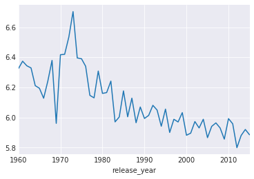

```python
df.groupby('release_year')['vote_average'].mean().plot(kind='line');
```

Let's see which directors where the most hardworking:

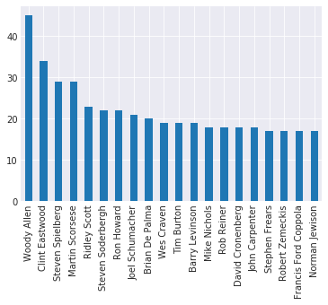

```python
#most active directors
df.director.value_counts().head(20).plot(kind='bar');
```

### Research Question 1: Which genres are most popular from year to year?

Let's only pick the most relevant features.

```python
df1 = df.loc[:,['id', 'release_year', 'popularity', 'genres']]
```

```python
df1.head()
```

|  | id | release_year | popularity | genres |
| --- | --- | --- | --- | --- |
| 0 | 135397 | 2015 | 32.985763 | Action\|Adventure\|Science Fiction\|Thriller |
| 1 | 76341 | 2015 | 28.419936 | Action\|Adventure\|Science Fiction\|Thriller |
| 2 | 262500 | 2015 | 13.112507 | Adventure\|Science Fiction\|Thriller |
| 3 | 140607 | 2015 | 11.173104 | Action\|Adventure\|Science Fiction\|Fantasy |
| 4 | 168259 | 2015 | 9.335014 | Action\|Crime\|Thriller |

We need to split them up first to get an idea, which genres were popular from year to year:

```python
df1.genres = df1.genres.str.split('|') # split by | to get an array of genres
```

```python
df1.head()
```

|  | id | release_year | popularity | genres |
| --- | --- | --- | --- | --- |
| 0 | 135397 | 2015 | 32.985763 | [Action, Adventure, Science Fiction, Thriller] |
| 1 | 76341 | 2015 | 28.419936 | [Action, Adventure, Science Fiction, Thriller] |
| 2 | 262500 | 2015 | 13.112507 | [Adventure, Science Fiction, Thriller] |
| 3 | 140607 | 2015 | 11.173104 | [Action, Adventure, Science Fiction, Fantasy] |
| 4 | 168259 | 2015 | 9.335014 | [Action, Crime, Thriller] |

We will create a new row for each genre and join it with the original data frame to get a more suitable data frame for calculating popularity:

```python
df1_temp = df1.genres.apply(pd.Series).stack().reset_index(level=1, drop=True).to_frame('genres') # makes series from the array and explode the genre arrays to get them into one row each
```

```python
df1_temp.head()
```

|  | genres |
| --- | --- |
| 0 | Action |
| 0 | Adventure |
| 0 | Science Fiction |
| 0 | Thriller |
| 1 | Action |

```python
df1 = df1.drop(['genres'], axis=1).join(df1_temp, how='inner') # join on the index without 'on=' parameter
```

```python
df1.head(10)
```

|  | id | release_year | popularity | genres |
| --- | --- | --- | --- | --- |
| 0 | 135397 | 2015 | 32.985763 | Action |
| 0 | 135397 | 2015 | 32.985763 | Adventure |
| 0 | 135397 | 2015 | 32.985763 | Science Fiction |
| 0 | 135397 | 2015 | 32.985763 | Thriller |
| 1 | 76341 | 2015 | 28.419936 | Action |
| 1 | 76341 | 2015 | 28.419936 | Adventure |
| 1 | 76341 | 2015 | 28.419936 | Science Fiction |
| 1 | 76341 | 2015 | 28.419936 | Thriller |
| 2 | 262500 | 2015 | 13.112507 | Adventure |
| 2 | 262500 | 2015 | 13.112507 | Science Fiction |

> We now have a data frame containing each unique movie id and it's popularity and a range of corresponding genres

Let's create some dummy values to simplify calculations even more:

```python
df1=pd.get_dummies(df1, columns=['genres']) # get dummy values only from genre column
```

```python
df1.head(10)
```

|  | id | release_year | popularity | genres_Action | genres_Adventure | genres_Animation | genres_Comedy | genres_Crime | genres_Documentary | genres_Drama | genres_Family | genres_Fantasy | genres_Foreign | genres_History | genres_Horror | genres_Music | genres_Mystery | genres_Romance | genres_Science Fiction | genres_TV Movie | genres_Thriller | genres_War | genres_Western |
| --- | --- | --- | --- | --- | --- | --- | --- | --- | --- | --- | --- | --- | --- | --- | --- | --- | --- | --- | --- | --- | --- | --- | --- |
| 0 | 135397 | 2015 | 32.985763 | 1 | 0 | 0 | 0 | 0 | 0 | 0 | 0 | 0 | 0 | 0 | 0 | 0 | 0 | 0 | 0 | 0 | 0 | 0 | 0 |
| 0 | 135397 | 2015 | 32.985763 | 0 | 1 | 0 | 0 | 0 | 0 | 0 | 0 | 0 | 0 | 0 | 0 | 0 | 0 | 0 | 0 | 0 | 0 | 0 | 0 |
| 0 | 135397 | 2015 | 32.985763 | 0 | 0 | 0 | 0 | 0 | 0 | 0 | 0 | 0 | 0 | 0 | 0 | 0 | 0 | 0 | 1 | 0 | 0 | 0 | 0 |
| 0 | 135397 | 2015 | 32.985763 | 0 | 0 | 0 | 0 | 0 | 0 | 0 | 0 | 0 | 0 | 0 | 0 | 0 | 0 | 0 | 0 | 0 | 1 | 0 | 0 |
| 1 | 76341 | 2015 | 28.419936 | 1 | 0 | 0 | 0 | 0 | 0 | 0 | 0 | 0 | 0 | 0 | 0 | 0 | 0 | 0 | 0 | 0 | 0 | 0 | 0 |
| 1 | 76341 | 2015 | 28.419936 | 0 | 1 | 0 | 0 | 0 | 0 | 0 | 0 | 0 | 0 | 0 | 0 | 0 | 0 | 0 | 0 | 0 | 0 | 0 | 0 |
| 1 | 76341 | 2015 | 28.419936 | 0 | 0 | 0 | 0 | 0 | 0 | 0 | 0 | 0 | 0 | 0 | 0 | 0 | 0 | 0 | 1 | 0 | 0 | 0 | 0 |
| 1 | 76341 | 2015 | 28.419936 | 0 | 0 | 0 | 0 | 0 | 0 | 0 | 0 | 0 | 0 | 0 | 0 | 0 | 0 | 0 | 0 | 0 | 1 | 0 | 0 |
| 2 | 262500 | 2015 | 13.112507 | 0 | 1 | 0 | 0 | 0 | 0 | 0 | 0 | 0 | 0 | 0 | 0 | 0 | 0 | 0 | 0 | 0 | 0 | 0 | 0 |
| 2 | 262500 | 2015 | 13.112507 | 0 | 0 | 0 | 0 | 0 | 0 | 0 | 0 | 0 | 0 | 0 | 0 | 0 | 0 | 0 | 1 | 0 | 0 | 0 | 0 |

We want to have a score for popularity for each genre, so we need to get the average popularity per genre per year. To achieve that, we multiply the popularity with each dummy variable. Subsequently, we group by ID and year. The genre having the maximum average score is regarded as teh most popular!

**(1)** multiply popularity with each genre for each movie

```python
pop = df1.columns[2] # get popularity column
gcols = df1.columns[3:] # get genre columns
for g in gcols: # for each genre columns
    df1[g] *= df1[pop] # multiply popularity score with dummy value
```

```python
df1.head()
```

|  | id | release_year | popularity | genres_Action | genres_Adventure | genres_Animation | genres_Comedy | genres_Crime | genres_Documentary | genres_Drama | genres_Family | genres_Fantasy | genres_Foreign | genres_History | genres_Horror | genres_Music | genres_Mystery | genres_Romance | genres_Science Fiction | genres_TV Movie | genres_Thriller | genres_War | genres_Western |
| --- | --- | --- | --- | --- | --- | --- | --- | --- | --- | --- | --- | --- | --- | --- | --- | --- | --- | --- | --- | --- | --- | --- | --- |
| 0 | 135397 | 2015 | 32.985763 | 32.985763 | 0.000000 | 0.0 | 0.0 | 0.0 | 0.0 | 0.0 | 0.0 | 0.0 | 0.0 | 0.0 | 0.0 | 0.0 | 0.0 | 0.0 | 0.000000 | 0.0 | 0.000000 | 0.0 | 0.0 |
| 0 | 135397 | 2015 | 32.985763 | 0.000000 | 32.985763 | 0.0 | 0.0 | 0.0 | 0.0 | 0.0 | 0.0 | 0.0 | 0.0 | 0.0 | 0.0 | 0.0 | 0.0 | 0.0 | 0.000000 | 0.0 | 0.000000 | 0.0 | 0.0 |
| 0 | 135397 | 2015 | 32.985763 | 0.000000 | 0.000000 | 0.0 | 0.0 | 0.0 | 0.0 | 0.0 | 0.0 | 0.0 | 0.0 | 0.0 | 0.0 | 0.0 | 0.0 | 0.0 | 32.985763 | 0.0 | 0.000000 | 0.0 | 0.0 |
| 0 | 135397 | 2015 | 32.985763 | 0.000000 | 0.000000 | 0.0 | 0.0 | 0.0 | 0.0 | 0.0 | 0.0 | 0.0 | 0.0 | 0.0 | 0.0 | 0.0 | 0.0 | 0.0 | 0.000000 | 0.0 | 32.985763 | 0.0 | 0.0 |
| 1 | 76341 | 2015 | 28.419936 | 28.419936 | 0.000000 | 0.0 | 0.0 | 0.0 | 0.0 | 0.0 | 0.0 | 0.0 | 0.0 | 0.0 | 0.0 | 0.0 | 0.0 | 0.0 | 0.000000 | 0.0 | 0.000000 | 0.0 | 0.0 |

**(2)** Drop the popularity column.

```python
df1.drop(['popularity'], axis=1, inplace=True) # drop popularity, as we don't need it anymore
```

```python
df1.head()
```

|  | id | release_year | genres_Action | genres_Adventure | genres_Animation | genres_Comedy | genres_Crime | genres_Documentary | genres_Drama | genres_Family | genres_Fantasy | genres_Foreign | genres_History | genres_Horror | genres_Music | genres_Mystery | genres_Romance | genres_Science Fiction | genres_TV Movie | genres_Thriller | genres_War | genres_Western |
| --- | --- | --- | --- | --- | --- | --- | --- | --- | --- | --- | --- | --- | --- | --- | --- | --- | --- | --- | --- | --- | --- | --- |
| 0 | 135397 | 2015 | 32.985763 | 0.000000 | 0.0 | 0.0 | 0.0 | 0.0 | 0.0 | 0.0 | 0.0 | 0.0 | 0.0 | 0.0 | 0.0 | 0.0 | 0.0 | 0.000000 | 0.0 | 0.000000 | 0.0 | 0.0 |
| 0 | 135397 | 2015 | 0.000000 | 32.985763 | 0.0 | 0.0 | 0.0 | 0.0 | 0.0 | 0.0 | 0.0 | 0.0 | 0.0 | 0.0 | 0.0 | 0.0 | 0.0 | 0.000000 | 0.0 | 0.000000 | 0.0 | 0.0 |
| 0 | 135397 | 2015 | 0.000000 | 0.000000 | 0.0 | 0.0 | 0.0 | 0.0 | 0.0 | 0.0 | 0.0 | 0.0 | 0.0 | 0.0 | 0.0 | 0.0 | 0.0 | 32.985763 | 0.0 | 0.000000 | 0.0 | 0.0 |
| 0 | 135397 | 2015 | 0.000000 | 0.000000 | 0.0 | 0.0 | 0.0 | 0.0 | 0.0 | 0.0 | 0.0 | 0.0 | 0.0 | 0.0 | 0.0 | 0.0 | 0.0 | 0.000000 | 0.0 | 32.985763 | 0.0 | 0.0 |
| 1 | 76341 | 2015 | 28.419936 | 0.000000 | 0.0 | 0.0 | 0.0 | 0.0 | 0.0 | 0.0 | 0.0 | 0.0 | 0.0 | 0.0 | 0.0 | 0.0 | 0.0 | 0.000000 | 0.0 | 0.000000 | 0.0 | 0.0 |

**(3)** Group by *id* and *year*

```python
df1 = df1.groupby(['id', 'release_year']).sum() # sum up the dummies for each user to reduce number of rows without affecting result
```

```python
df1.head()
```

| id | release_year | genres_Action | genres_Adventure | genres_Animation | genres_Comedy | genres_Crime | genres_Documentary | genres_Drama | genres_Family | genres_Fantasy | genres_Foreign | genres_History | genres_Horror | genres_Music | genres_Mystery | genres_Romance | genres_Science Fiction | genres_TV Movie | genres_Thriller | genres_War | genres_Western |
| --- | --- | --- | --- | --- | --- | --- | --- | --- | --- | --- | --- | --- | --- | --- | --- | --- | --- | --- | --- | --- | --- |
| 5 | 1995 | 0.000000 | 0.000000 | 0.000000 | 1.234890 | 0.000000 | 0.0 | 0.000000 | 0.000000 | 0.0 | 0.0 | 0.0 | 0.0 | 0.0 | 0.0 | 0.000000 | 0.000000 | 0.0 | 0.000000 | 0.0 | 0.0 |
| 6 | 1993 | 0.815631 | 0.000000 | 0.000000 | 0.000000 | 0.815631 | 0.0 | 0.000000 | 0.000000 | 0.0 | 0.0 | 0.0 | 0.0 | 0.0 | 0.0 | 0.000000 | 0.000000 | 0.0 | 0.815631 | 0.0 | 0.0 |
| 11 | 1977 | 12.037933 | 12.037933 | 0.000000 | 0.000000 | 0.000000 | 0.0 | 0.000000 | 0.000000 | 0.0 | 0.0 | 0.0 | 0.0 | 0.0 | 0.0 | 0.000000 | 12.037933 | 0.0 | 0.000000 | 0.0 | 0.0 |
| 12 | 2003 | 0.000000 | 0.000000 | 3.440519 | 0.000000 | 0.000000 | 0.0 | 0.000000 | 3.440519 | 0.0 | 0.0 | 0.0 | 0.0 | 0.0 | 0.0 | 0.000000 | 0.000000 | 0.0 | 0.000000 | 0.0 | 0.0 |
| 13 | 1994 | 0.000000 | 0.000000 | 0.000000 | 6.715966 | 0.000000 | 0.0 | 6.715966 | 0.000000 | 0.0 | 0.0 | 0.0 | 0.0 | 0.0 | 0.0 | 6.715966 | 0.000000 | 0.0 | 0.000000 | 0.0 | 0.0 |

**(4)** get rid of the long column names

```python
df1.rename(columns=lambda x: x.replace('genres_', '').lower(), inplace=True) # make column names shorter
```

```python
df1.head()
```

| id | release_year | action | adventure | animation | comedy | crime | documentary | drama | family | fantasy | foreign | history | horror | music | mystery | romance | science fiction | tv movie | thriller | war | western |
| --- | --- | --- | --- | --- | --- | --- | --- | --- | --- | --- | --- | --- | --- | --- | --- | --- | --- | --- | --- | --- | --- |
| 5 | 1995 | 0.000000 | 0.000000 | 0.000000 | 1.234890 | 0.000000 | 0.0 | 0.000000 | 0.000000 | 0.0 | 0.0 | 0.0 | 0.0 | 0.0 | 0.0 | 0.000000 | 0.000000 | 0.0 | 0.000000 | 0.0 | 0.0 |
| 6 | 1993 | 0.815631 | 0.000000 | 0.000000 | 0.000000 | 0.815631 | 0.0 | 0.000000 | 0.000000 | 0.0 | 0.0 | 0.0 | 0.0 | 0.0 | 0.0 | 0.000000 | 0.000000 | 0.0 | 0.815631 | 0.0 | 0.0 |
| 11 | 1977 | 12.037933 | 12.037933 | 0.000000 | 0.000000 | 0.000000 | 0.0 | 0.000000 | 0.000000 | 0.0 | 0.0 | 0.0 | 0.0 | 0.0 | 0.0 | 0.000000 | 12.037933 | 0.0 | 0.000000 | 0.0 | 0.0 |
| 12 | 2003 | 0.000000 | 0.000000 | 3.440519 | 0.000000 | 0.000000 | 0.0 | 0.000000 | 3.440519 | 0.0 | 0.0 | 0.0 | 0.0 | 0.0 | 0.0 | 0.000000 | 0.000000 | 0.0 | 0.000000 | 0.0 | 0.0 |
| 13 | 1994 | 0.000000 | 0.000000 | 0.000000 | 6.715966 | 0.000000 | 0.0 | 6.715966 | 0.000000 | 0.0 | 0.0 | 0.0 | 0.0 | 0.0 | 0.0 | 6.715966 | 0.000000 | 0.0 | 0.000000 | 0.0 | 0.0 |

**(5)** Take each year's average

```python
df1 = df1.groupby('release_year').mean() # get the mean score for each year for each genre
```

```python
df1.head()
```

| release_year | action | adventure | animation | comedy | crime | documentary | drama | family | fantasy | foreign | history | horror | music | mystery | romance | science fiction | tv movie | thriller | war | western |
| --- | --- | --- | --- | --- | --- | --- | --- | --- | --- | --- | --- | --- | --- | --- | --- | --- | --- | --- | --- | --- |
| 1960 | 0.147681 | 0.109528 | 0.000000 | 0.099000 | 0.021655 | 0.0 | 0.230061 | 0.026068 | 0.026765 | 0.006092 | 0.064432 | 0.129380 | 0.013235 | 0.000000 | 0.101480 | 0.030741 | 0.0 | 0.152233 | 0.014116 | 0.106455 |
| 1961 | 0.082625 | 0.148514 | 0.084903 | 0.219303 | 0.052033 | 0.0 | 0.223088 | 0.121891 | 0.009940 | 0.003666 | 0.032367 | 0.024637 | 0.036435 | 0.022993 | 0.096202 | 0.035368 | 0.0 | 0.000000 | 0.034270 | 0.020325 |
| 1962 | 0.177236 | 0.206175 | 0.000000 | 0.042685 | 0.044326 | 0.0 | 0.257250 | 0.020216 | 0.007361 | 0.007361 | 0.075008 | 0.028026 | 0.010123 | 0.032403 | 0.057128 | 0.011201 | 0.0 | 0.166377 | 0.047453 | 0.038829 |
| 1963 | 0.111968 | 0.149983 | 0.064130 | 0.169949 | 0.064984 | 0.0 | 0.123289 | 0.075232 | 0.012592 | 0.020685 | 0.056661 | 0.099768 | 0.000000 | 0.074300 | 0.094017 | 0.027520 | 0.0 | 0.211744 | 0.019539 | 0.014527 |
| 1964 | 0.096796 | 0.087670 | 0.021226 | 0.187135 | 0.062307 | 0.0 | 0.173723 | 0.083647 | 0.057123 | 0.003624 | 0.022598 | 0.027093 | 0.089738 | 0.029342 | 0.047483 | 0.021584 | 0.0 | 0.133410 | 0.066497 | 0.003040 |

**(6)** Take the genre with the maximum score for each year

```python
df11 = df1.idxmax(axis=1).to_frame() # for each year get the column name of the most popular score (i.e. most popular genre per year)
```

```python
df11.columns = ['popular_genre']
df11
```

| release_year | popular_genre |
| --- | --- |
| 1960 | drama |
| 1961 | drama |
| 1962 | drama |
| 1963 | thriller |
| 1964 | comedy |
| 1965 | drama |
| 1966 | drama |
| 1967 | drama |
| 1968 | drama |
| 1969 | drama |
| 1970 | drama |
| 1971 | drama |
| 1972 | drama |
| 1973 | drama |
| 1974 | drama |
| 1975 | drama |
| 1976 | drama |
| 1977 | adventure |
| 1978 | drama |
| 1979 | drama |
| 1980 | action |
| 1981 | adventure |
| 1982 | drama |
| 1983 | action |
| 1984 | action |
| 1985 | comedy |
| 1986 | drama |
| 1987 | comedy |
| 1988 | comedy |
| 1989 | comedy |
| 1990 | drama |
| 1991 | comedy |
| 1992 | comedy |
| 1993 | drama |
| 1994 | drama |
| 1995 | drama |
| 1996 | drama |
| 1997 | thriller |
| 1998 | drama |
| 1999 | drama |
| 2000 | comedy |
| 2001 | drama |
| 2002 | drama |
| 2003 | action |
| 2004 | comedy |
| 2005 | drama |
| 2006 | drama |
| 2007 | drama |
| 2008 | drama |
| 2009 | drama |
| 2010 | drama |
| 2011 | drama |
| 2012 | drama |
| 2013 | drama |
| 2014 | drama |
| 2015 | drama |

Taking a look at the counts, the 'drama' genre seems to be a clear winner:

```python
# get counts for each year to determine which genre was voted most popular genre
df11['count'] = 1
df11 = df11.groupby('popular_genre').count()
df11.sort_values('count', ascending=False, inplace=True)
df11
```

| popular_genre | count |
| --- | --- |
| drama | 39 |
| comedy | 9 |
| action | 4 |
| adventure | 2 |
| thriller | 2 |

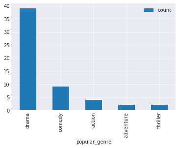

```python
df11.plot(kind='bar');
```

### Research Question 2: What kinds of properties are associated with movies that have high revenues?

```python
df2 = df_clean.drop(['imdb_id', 'original_title', 'cast', 'director', 'tagline', 'keywords', 'overview', 'genres', 'production_companies', 'release_date'], axis=1)
```

```python
df2.describe()
```

|  | id | popularity | runtime | vote_count | vote_average | release_year | budget_adj | revenue_adj |
| --- | --- | --- | --- | --- | --- | --- | --- | --- |
| count | 3694.000000 | 3694.000000 | 3694.000000 | 3694.000000 | 3694.000000 | 3694.000000 | 3.694000e+03 | 3.694000e+03 |
| mean | 40489.269897 | 1.088900 | 108.432593 | 447.193286 | 6.155604 | 2001.290471 | 4.001886e+07 | 1.082165e+08 |
| std | 68022.417595 | 1.219356 | 19.109988 | 696.404019 | 0.772514 | 11.149955 | 3.693230e+07 | 1.347931e+08 |
| min | 5.000000 | 0.001117 | 15.000000 | 10.000000 | 3.800000 | 1960.000000 | 9.693980e-01 | 2.370705e+00 |
| 25% | 6974.000000 | 0.453438 | 95.000000 | 67.250000 | 5.600000 | 1995.000000 | 1.265582e+07 | 1.738005e+07 |
| 50% | 11376.000000 | 0.779492 | 105.000000 | 192.500000 | 6.200000 | 2004.000000 | 2.850616e+07 | 5.761980e+07 |
| 75% | 38703.500000 | 1.304322 | 118.000000 | 513.750000 | 6.700000 | 2010.000000 | 5.616368e+07 | 1.445441e+08 |
| max | 417859.000000 | 28.419936 | 338.000000 | 7375.000000 | 8.400000 | 2015.000000 | 1.778701e+08 | 6.989810e+08 |

```python
df2_high = df2.query('revenue_adj > revenue_adj.mean()')
df2_high.describe()
```

|  | id | popularity | runtime | vote_count | vote_average | release_year | budget_adj | revenue_adj |
| --- | --- | --- | --- | --- | --- | --- | --- | --- |
| count | 1187.000000 | 1187.000000 | 1187.000000 | 1187.000000 | 1187.000000 | 1187.000000 | 1.187000e+03 | 1.187000e+03 |
| mean | 31180.534962 | 1.778344 | 113.812131 | 909.234204 | 6.374979 | 2000.023589 | 6.799052e+07 | 2.605334e+08 |
| std | 58142.524464 | 1.716012 | 20.448123 | 971.006811 | 0.702121 | 11.905238 | 4.248283e+07 | 1.426268e+08 |
| min | 14.000000 | 0.017498 | 69.000000 | 13.000000 | 4.100000 | 1960.000000 | 2.248029e+02 | 1.082936e+08 |
| 25% | 1708.000000 | 0.911700 | 99.000000 | 279.000000 | 5.900000 | 1994.000000 | 3.348791e+07 | 1.495761e+08 |
| 50% | 9443.000000 | 1.359987 | 111.000000 | 583.000000 | 6.400000 | 2003.000000 | 6.098403e+07 | 2.113635e+08 |
| 75% | 24995.500000 | 2.133316 | 125.000000 | 1148.500000 | 6.900000 | 2009.000000 | 9.489013e+07 | 3.317850e+08 |
| max | 417859.000000 | 28.419936 | 216.000000 | 7375.000000 | 8.100000 | 2015.000000 | 1.778701e+08 | 6.989810e+08 |

conduct some t-tests to proof that the findings are significant:

```python
ttest_ind(df2_high.vote_average, df2.vote_average)
```

```
Ttest_indResult(statistic=8.697250884749133, pvalue=4.5798673489521535e-18)
```

```python
ttest_ind(df2_high.budget_adj, df2.budget_adj)
```

```
Ttest_indResult(statistic=21.857973063677463, pvalue=4.033275441657082e-101)
```

```python
ttest_ind(df2_high.runtime, df2.runtime)
```

```
Ttest_indResult(statistic=8.2924831410545963, pvalue=1.4198202232216247e-16)
```

```python
ttest_ind(df2_high.release_year, df2.release_year)
```

```
Ttest_indResult(statistic=-3.3489775387504253, pvalue=0.00081725447944836274)
```

# General findings:

[output not shown]

# Research question 3: Are movies from before 2000 better than after 2000?

To answer this question, let's split the dataset up into two categories:

movies released before 2000 and after 2000

```python
df3 = df.loc[:, ['id', 'release_year', 'vote_average']]
df3.head()
```

|  | id | release_year | vote_average |
| --- | --- | --- | --- |
| 0 | 135397 | 2015 | 6.5 |
| 1 | 76341 | 2015 | 7.1 |
| 2 | 262500 | 2015 | 6.3 |
| 3 | 140607 | 2015 | 7.5 |
| 4 | 168259 | 2015 | 7.3 |

```python
# create new binary column which determines if a movie was pre 2000 or post 2000
df3['after_2000'] = df3.release_year >= 2000
df3.drop(['release_year'], axis=1, inplace=True)
df3.drop(['id'], axis=1, inplace=True)
df3.head()
```

|  | vote_average | after_2000 |
| --- | --- | --- |
| 0 | 6.5 | True |
| 1 | 7.1 | True |
| 2 | 6.3 | True |
| 3 | 7.5 | True |
| 4 | 7.3 | True |

```python
# get averages for pre and post 2000
df3_mean = df3.groupby('after_2000').mean()
df3_mean
```

| after_2000 | vote_average |
| --- | --- |
| False | 6.097025 |
| True | 5.912055 |

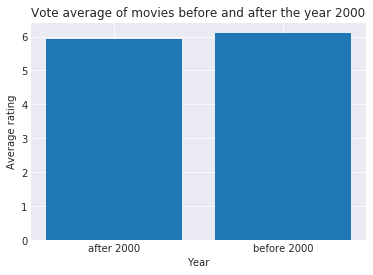

```python
plt.bar(['before 2000','after 2000'], df3_mean['vote_average'])
plt.title("Vote average of movies before and after the year 2000")
plt.xlabel("Year")
plt.ylabel("Average rating");
```

> Calculating the vote_average, it turns out that movies after 2000 have a slightly lower rating than before 2000. Let's test for statistic significance using a T-test:

```python
cat1 = df3.query("after_2000 == True")
cat2 = df3.query("after_2000 == False")

ttest_ind(cat2.vote_average, cat1.vote_average)
```

```
Ttest_indResult(statistic=9.812039641435133, pvalue=1.2407748897486369e-22)
```

The t-statistic indicates that the difference between the two sets is around 9.81 times higher than the difference of the elements within each set. What is more, the p-value is very small, which indicates that movies before 2000 have siginficantly higher vote averages than after 2000!

## Conclusions

> Following steps have been conducted as part of the analysis:

> The dataset has been checked for its general properties and cleaned in terms of duplicates, zero or NaN values and outliers. Also some exploratory statistics have been conducted.

> In the context of the first research question it was found, that the 'drama' genre is the most popular genre over many years. Within the scope of the second question it was shown what the characteristics of movies are, which generate high revenues: The are genrerally more expensive, have longer runtimes and are rated better by the audience. The third question compares movie rating between movies before and after 2000 and comes to the conclusion that movies before 2000 have significantly higher ratings than after.

### Limitations:

> The vote averages have not been weighted amongst the number of votes. Many movies did not have data for revenue or budget which decreases the size of the data set. Drama is the most 'popular' genre, however more than one genre were assigned to most movies and it seems that most movies have the characteristics of a drama. E.g. a movie can be an action movie but is also a drama. Or it can be comedy and a drama. A further question arises, if 'drama' can be regarded as a real genre or if almost every movie has drama elements in them, meaning that 'drama' would not make a good match for a genre category.

```python
from subprocess import call
call(['python', '-m', 'nbconvert', 'Investigate_a_Dataset.ipynb'])
```

```
0
```